# Take-home Exercise 1

In this Take-home exercise, I will explore demographic of the city of Engagement, Ohio USA by using appropriate static statistical graphics methods. The data should be processed by using appropriate [`tidyverse`](https://www.tidyverse.org/) family of packages and the statistical graphics must be prepared using [`ggplot2`](https://ggplot2.tidyverse.org/) and its extensions.

Huang Yaping www.linkedin.com/in/huang-yaping (School of Computing and Information Systems)https://scis.smu.edu.sg/  
2022-04-22

# Overview

In this take-home exercise, appropriate static statistical graphics methods are used to reveal the demographic of the city of Engagement, Ohio USA.

The data should be processed by using appropriate tidyverse family of packages and the statistical graphics must be prepared using ggplot2 and its extensions.

# Getting Started

Before we get started, it is important for us to ensure that the required R packages have been installed. If yes, we will load the R packages. If they have yet to be installed, we will install the R packages and load them onto R environment.

The chunk code below will do the trick.

```r
packages = c('tidyverse', 'ggridges')

for (p in packages){
  if(!require(p, character.only = T)){
    install.packages(p)
  }
  library(p, character.only = T)
}
```

# Importing Data

The code chunk below import *Participants.csv*, *Jobs.csv* , *Apartments.csv* from the data sub folder into R by using [`read_csv()`](https://readr.tidyverse.org/reference/read_delim.html) of [**readr**](https://readr.tidyverse.org/) packages and save them as tibble data frames called *participants_data*, *apartments_data*, and *jobs_data*.

```r
participants_data <- read_csv("data/Participants.csv")
apartments_data <- read_csv("data/Apartments.csv")
jobs_data <- read_csv("data/Jobs.csv")
```

# Histogram Chart on Age vs haveKids

The code chunk below plots a histogram chart by using geom_histogram of ggplot2.

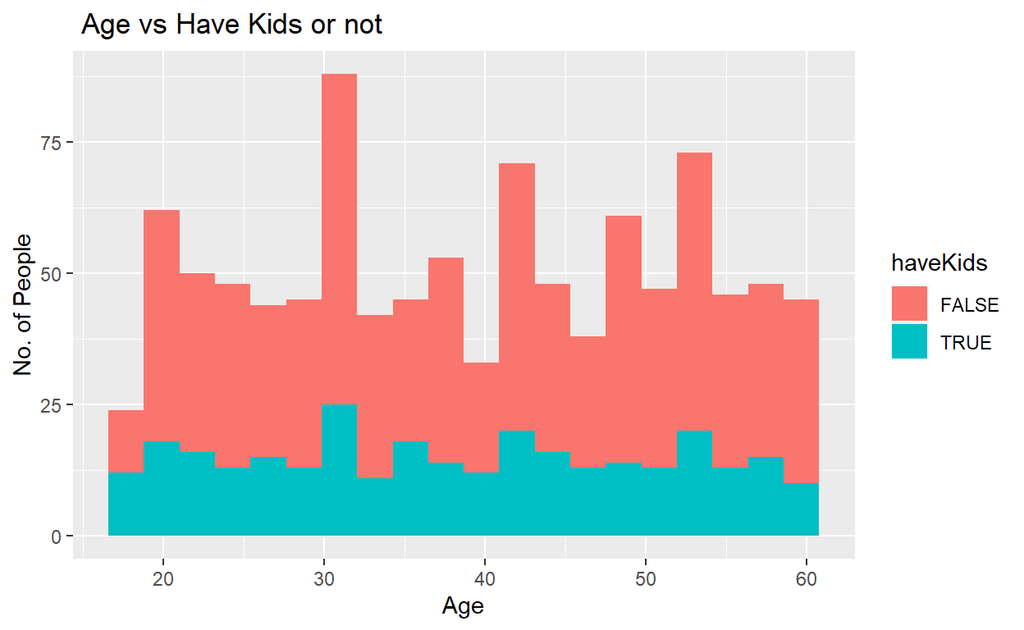

```r
ggplot(data = participants_data,
       aes(x = age, fill = haveKids)) +
  geom_histogram(bins = 20)+
  labs(x = "Age",
       y = "No. of People",
       title = " Age vs Have Kids or not")
```

# Bar Chart on Education Level

The code chunk below plots a bar chart by using geom_bar of ggplot2.

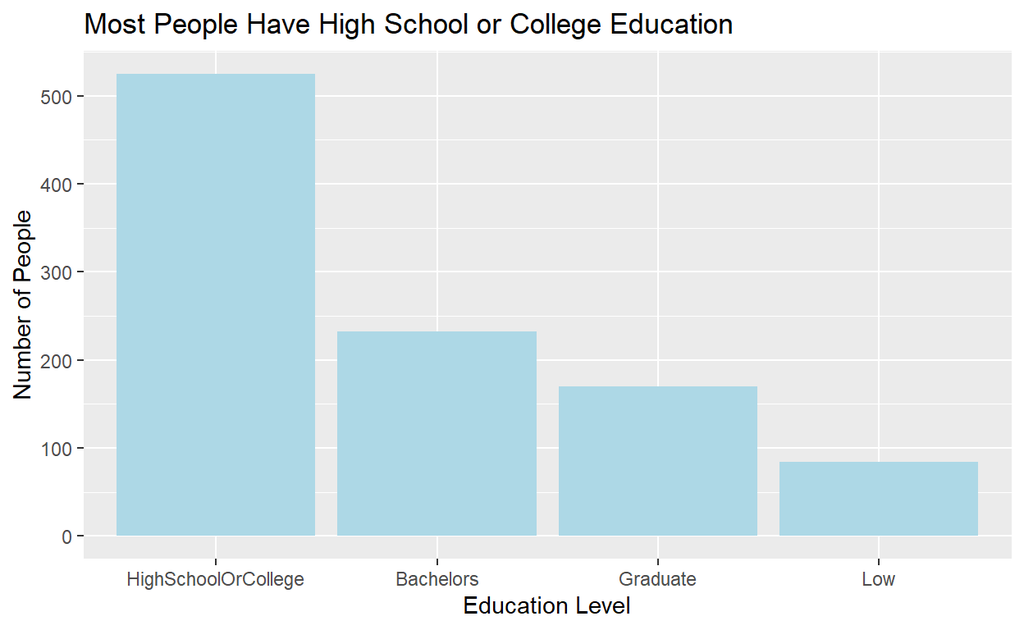

```r
ggplot(data = participants_data,
       aes(x = reorder(educationLevel, educationLevel, function(x)-length(x)))) +
  geom_bar(fill = "lightblue")+
  labs(x = "Education Level",
       y = "Number of People",
       title = "Most People Have High School or College Education")
```

# Boxplot: Joviality vs Education level

The code chunk below plots a boxplot by using geom_boxplot of ggplot. Please note that the data is ranked from high to low by reorder().

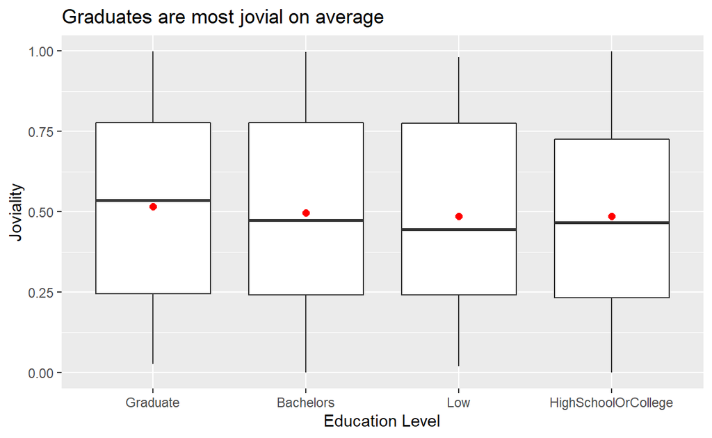

```r
ggplot(data = participants_data,
       aes( x =reorder(educationLevel, -joviality), y = joviality)) +
  geom_boxplot()+
  stat_summary(geom = "point",
               fun = "mean",
               colour = "red",
               size = 2)+
  labs( x = "Education Level",
        y = "Joviality",
        title = "Graduates are most jovial on average")
```

# Ridge Plot: Hourly Rate VS Education Level

The code chunk below plots a ridge plot of ggridges. Please note that the data is ranked by reorder().

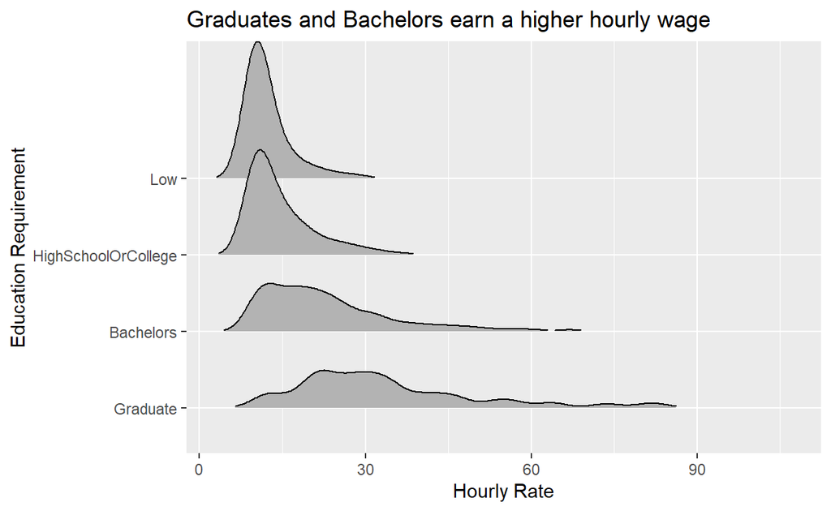

```r
ggplot(data = jobs_data,
       aes(x = hourlyRate, y = reorder( educationRequirement, -hourlyRate))) +
  geom_density_ridges(rel_min_height = 0.01)+
  labs(x = "Hourly Rate",
       y = "Education Requirement",
       title = "Graduates and Bachelors earn a higher hourly wage")
```